# Correlation network

```r
library(tidyverse)
```

```r
library(ggraph)
library(igraph)
```

# Data

In this part we are creating a data frame that contains the gene expression of 10 genes under 10 different experiements. The genes are connected in a network but we do not know what the network is, we only observe the gene expression after 10 different experiments (perturbations). Our goal here is to make inferences about the network that display the genes connections.

```r
# Data generation
set.seed(120)
variables_df <- data.frame(matrix(rnorm(100), ncol = 10))
names(variables_df) <- paste("Gene", c(1:10), sep = "")
rownames(variables_df) <- paste("Gene", c(1:10), sep = "")
```

# Correlations to estimate network structure

We are going to use correlations to estimate the weighted adjacency matrix so that we can find the network structure between the genes. The diagonal of the weighted adjacency matrix is set to 0 because we do not want to include the relationship of each gene with itself.

```r
# Correlation between genei and genej for i, i = 1, ..., 10
Correlation_matrix<- cor(variables_df)
diag(Correlation_matrix) = 0
Correlation_matrix <- abs(Correlation_matrix)
head(Correlation_matrix)
```

```
##           Gene1       Gene2     Gene3       Gene4      Gene5     Gene6
## Gene1 0.0000000 0.786485505 0.1379868 0.295942461 0.30323831 0.2173260
## Gene2 0.7864855 0.000000000 0.2785584 0.004339776 0.08420537 0.1839404
## Gene3 0.1379868 0.278558381 0.0000000 0.577131647 0.14406806 0.1206982
## Gene4 0.2959425 0.004339776 0.5771316 0.000000000 0.35787846 0.2881800
## Gene5 0.3032383 0.084205370 0.1440681 0.357878464 0.00000000 0.1915197
## Gene6 0.2173260 0.183940449 0.1206982 0.288179991 0.19151968 0.0000000
##           Gene7      Gene8     Gene9     Gene10
## Gene1 0.4544113 0.03651266 0.2300693 0.12772564
## Gene2 0.7204252 0.05589942 0.3734348 0.27262894
## Gene3 0.4087962 0.44822980 0.1773757 0.03065360
## Gene4 0.3850956 0.06761484 0.5599131 0.29751832
## Gene5 0.1970751 0.33773196 0.1147956 0.19697082
## Gene6 0.4610549 0.11351532 0.3980246 0.06855555
```

# Creating and edge data frame to plot the network

Think carefully what are we doing here and why are we doing it.

```r
# Formating correlation matrix into an edge data frame
d_edges_cor <- Correlation_matrix %>%
  as_tibble() %>%
  mutate(from = rownames(Correlation_matrix)) %>%
  gather(to, count, -from)
head(d_edges_cor)
```

```
## # A tibble: 6 x 3
##   from  to    count
##   <chr> <chr> <dbl>
## 1 Gene1 Gene1 0
## 2 Gene2 Gene1 0.786
## 3 Gene3 Gene1 0.138
## 4 Gene4 Gene1 0.296
## 5 Gene5 Gene1 0.303
## 6 Gene6 Gene1 0.217
```

# Plotting the estimated correlation network

Here we are using the packages igraph and ggraph

[figure not shown]

# What happens if we change the threshold for which edges are connected?

How does the network changes?

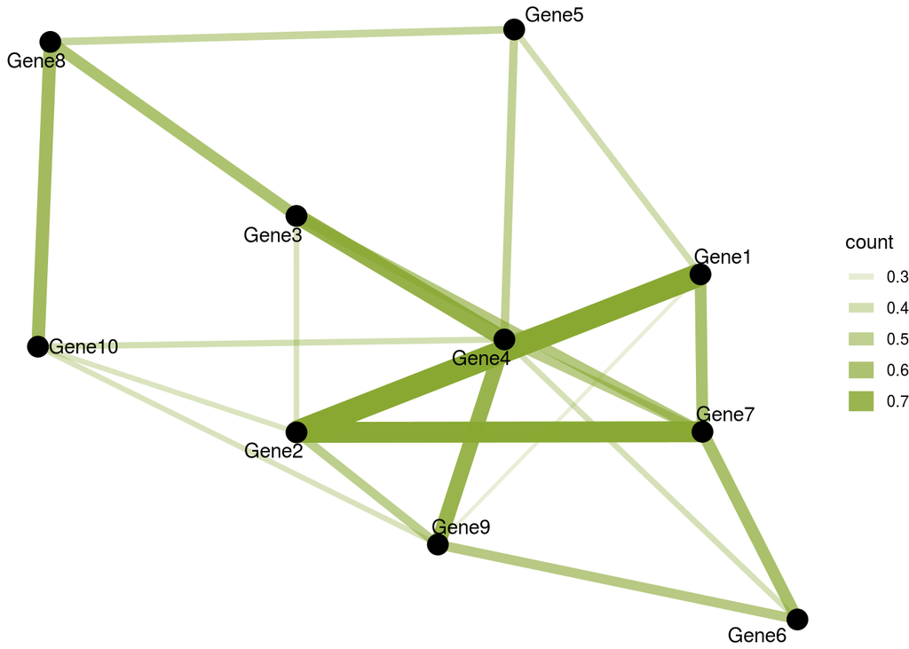

```r
set.seed(201)
d_edges_cor %>%
  dplyr::filter(count >= 0.23) %>%
graph_from_data_frame() %>%
  ggraph(layout = "fr") +
  geom_edge_link(aes(edge_alpha = count , edge_width = count), edge_color = "#89a832") +
  geom_node_point(size = 5) +
  geom_node_text(aes(label = name), repel = TRUE,
                 point.padding = unit(0.15, "lines")) +
  theme_void()
```

# Explore networks with different threshold values and different colors!